# Don Carlo

Oper in vier Akten (1867/1884)

Musik von

Giuseppe Verdi

Text von

François Joseph Pierre Méry und Camille Du Locle nach Friedrich Schiller

Er gebietet über ein Weltreich, und ist dabei doch ein zutiefst Verunsicherter. Philipp II. von Spanien ist nicht nur von Sorge um seine Herrschaft erfüllt, sondern fühlt sich auch von seiner Gattin Elisabeth von Valois, die seinen Sohn Carlo liebt und von diesem geliebt wird, betrogen und im Stich gelassen. Und über allem liegt der bedrohliche Schatten der Inquisition. Vergebens sucht er nach Vertrauen in dieser abweisenden Welt.

Mehrfach hat sich Giuseppe Verdi einer Dramenvorlage Friedrich Schillers zugewandt, um aus ihr ein Stück lebendiges Musiktheater zu formen. Mit »Don Carlo« gelang ihm das auf besonders eindrucksvolle Weise, zunächst in Gestalt einer französischen Grand Opéra, dann im Gewand eines italienischen Melodramma. Wirkungsvolle Tableaus mit großen Chor- und Ensembleszenen stehen kammerspielartige Passagen gegenüber, vor allem in Form von psychologisch sensibel durchgearbeiteten Duetten, in denen sich die Figuren wechselseitig abtasten und belauern, aber auch ihr Innerstes offenbaren. Intrigen werden gesponnen, es wird einander belogen und getäuscht – zuweilen aber bricht auch Licht ins Dunkel, wenn Freundschaft und Liebe beschworen werden, mit bezwingender Kraft und Ehrlichkeit. Verdis universales Welten- und Familiendrama ist eine Oper der großen Staatsakte wie der großen Emotionen, mit theatralischer Intensität und inspirierter Musik.

## Termine

Mi. 28. Juni 2023 19.00 Uhr

[Staatsoper Unter den Linden](https://www.staatsoper-berlin.de/de/ihr-besuch/anfahrt/staatsoper-unter-den-linden.35/)

Dauer: ca. 3:30 h inklusive einer Pause nach dem zweiten Akt

Sprache: In italienischer Sprache mit deutschen und englischen Übertiteln

Altersempfehlung: ab 16 Jahren  
Vorwort 45 Minuten vor Vorstellungsbeginn im Apollosaal

## Besetzung

- Musikalische Leitung
  - [Daniele Rustioni](https://www.staatsoper-berlin.de/de/kuenstler/daniele-rustioni.3262/)
- Inszenierung
  - [Philipp Himmelmann](https://www.staatsoper-berlin.de/de/kuenstler/philipp-himmelmann.1097/)
- Bühnenbild
  - [Johannes Leiacker](https://www.staatsoper-berlin.de/de/kuenstler/johannes-leiacker.1098/)
- Kostüme
  - [Klaus Bruns](https://www.staatsoper-berlin.de/de/kuenstler/klaus-bruns.1099/)
- Licht
  - Davy Cunningham
- Philipp II., König von Spanien
  - [René Pape](https://www.staatsoper-berlin.de/de/kuenstler/rene-pape.1101/)
- Don Carlo, Infant von Spanien
  - [Stefan Pop](https://www.staatsoper-berlin.de/de/kuenstler/stefan-pop.2913/)
- Rodrigo, Marquis von Posa
  - [George Petean](https://www.staatsoper-berlin.de/de/kuenstler/george-petean.2712/)
- Der Grossinquisitor
  - [Rafał Siwek](https://www.staatsoper-berlin.de/de/kuenstler/rafal-siwek.3365/)
- Ein Mönch
  - [Grigory Shkarupa](https://www.staatsoper-berlin.de/de/kuenstler/grigory-shkarupa.1055/)
- Elisabeth von Valois
  - [Aleksandra Kurzak](https://www.staatsoper-berlin.de/de/kuenstler/aleksandra-kurzak.1210/)
- Prinzessin Eboli
  - [Eve-Maud Hubeaux](https://www.staatsoper-berlin.de/de/kuenstler/eve-maud-hubeaux.3048/)
- Tebaldo
  - [Regina Koncz](https://www.staatsoper-berlin.de/de/kuenstler/regina-koncz.3028/)
- Stimme von oben
  - [Anna Malesza-Kutny](https://www.staatsoper-berlin.de/de/kuenstler/anna-malesza-kutny.2235/)
- Graf Lerma, Ein Herold
  - [Magnus Dietrich](https://www.staatsoper-berlin.de/de/kuenstler/magnus-dietrich.2854/)
- - [STAATSOPERNCHOR](https://www.staatsoper-berlin.de/de/kuenstler/staatsopernchor.1020/)
  - [STAATSKAPELLE BERLIN](https://www.staatsoper-berlin.de/de/kuenstler/staatskapelle-berlin.1019/)

## Medien

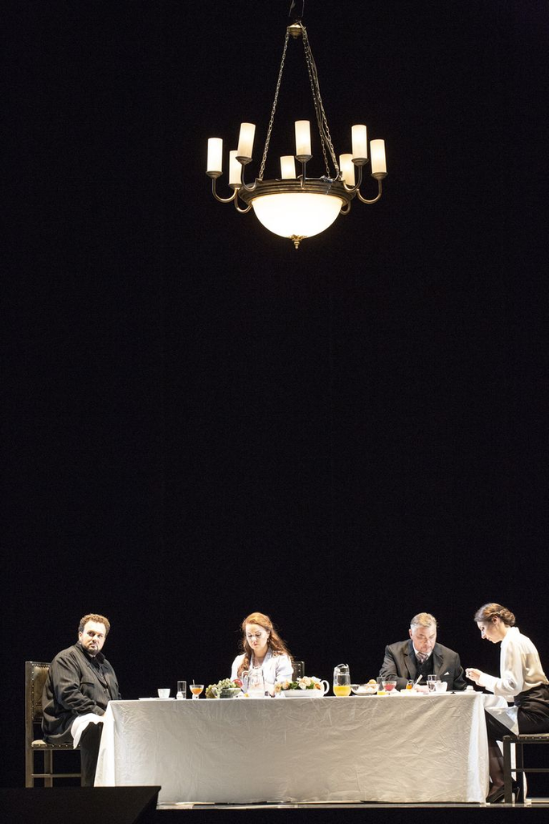

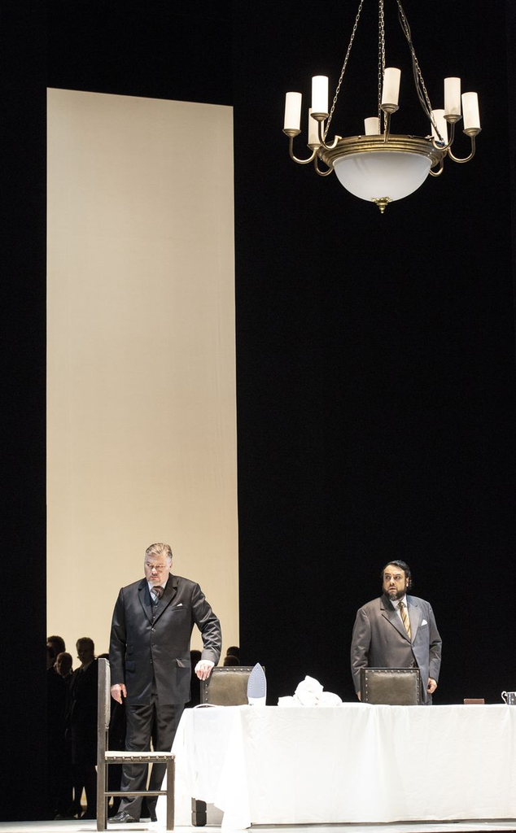

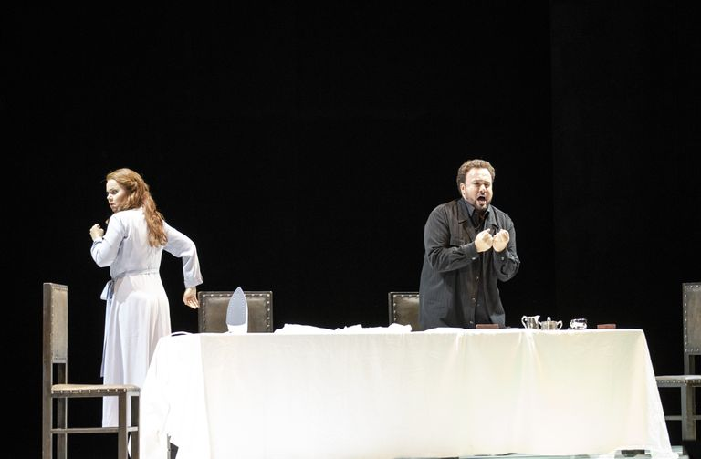

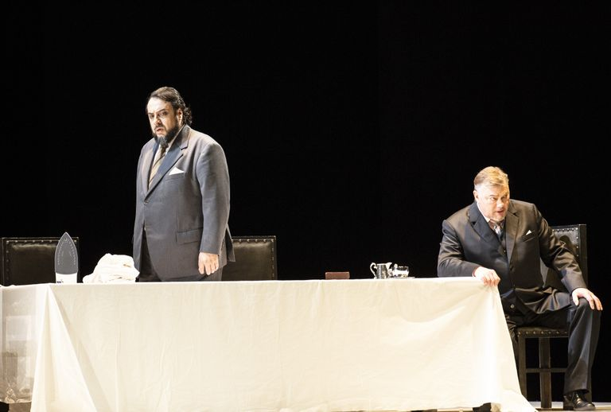

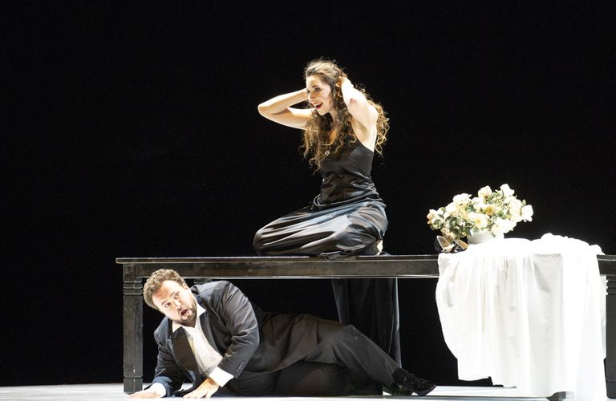

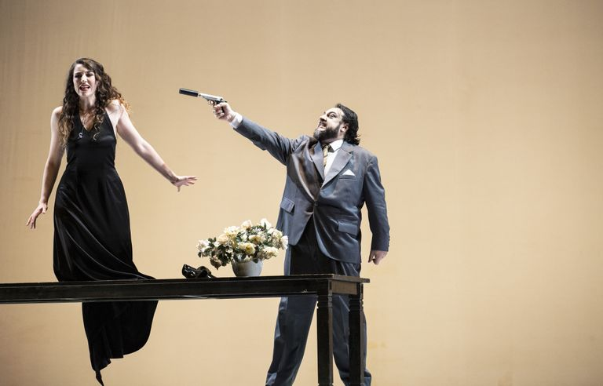